# Statistics challenge

Wifred Mambina

5/23/2020

#Loading tidyverse package that contains ggplo2 for data importation and data vizualization

```r
library(tidyverse)
library(lsr)
```

#Task 1:Data loading and inspection;since the data is a CSV file file I used read_csv() function which is related to tidyverse package

```r
statistics.data<-read_csv("C:/Users/Fred/Desktop/PU7_exercise2_ads.csv")
head(statistics.data)
```

```
## # A tibble: 6 x 5
##   gender   age animation tagline mean_att_overall
##   <chr>  <dbl> <chr>     <chr>              <dbl>
## 1 male      20 no        no                  2
## 2 male      21 no        no                  2.93
## 3 male      24 no        no                  3.4
## 4 male      45 no        no                  3.93
## 5 male      27 no        no                  2.47
## 6 male      20 no        no                  2.47
```

#Data inspection;since I have used the above head() to view the data ,I can add two more as shown below

```r
aggregate(mean_att_overall~animation+tagline,statistics.data,mean)
```

```
##   animation tagline mean_att_overall
## 1        no      no         3.003509
## 2       yes      no         2.950476
## 3        no     yes         3.169231
## 4       yes     yes         3.677778
```

```r
tail(statistics.data)
```

```
## # A tibble: 6 x 5
##   gender   age animation tagline mean_att_overall
##   <chr>  <dbl> <chr>     <chr>              <dbl>
## 1 female    20 no        yes                 2.87
## 2 female    31 no        yes                 3.47
## 3 female    20 no        yes                 3.27
## 4 female    42 no        yes                 2.4
## 5 female    23 no        yes                 2.47
## 6 female    19 no        yes                 4.93
```

```r
attach(statistics.data)
```

```r
tagline_v1<-as.factor(statistics.data$tagline)
head(tagline_v1)
```

```
## [1] no no no no no no
## Levels: no yes
```

```r
animation_v1<-as.factor(statistics.data$animation)
head(animation_v1)
```

```
## [1] no no no no no no
## Levels: no yes
```

The above output shows the conversion of tagline and animation to factors and its levels. #In order to confirm the conversion we can apply the function below

```r
class(tagline_v1)
```

```
## [1] "factor"
```

```r
class(animation_v1)
```

```
## [1] "factor"
```

#Pqrt b:Data visualization on mean_att_all using histogram

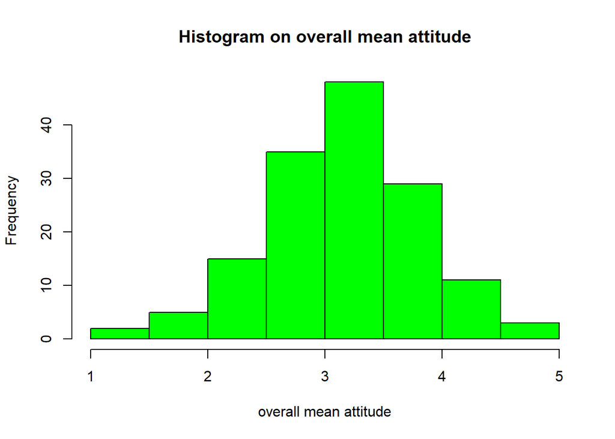

```r
hist(x=statistics.data$mean_att_overall,
     main="Histogram on overall mean attitude",
     col = "green",
     xlab = "overall mean attitude")
```

#Task 3;checking on the count levels by using xtab()

```r
xtabs(~animation_v1+tagline_v1,data = statistics.data)
```

```
##             tagline_v1
## animation_v1 no yes
##          no  38  39
##          yes 35  36
```

#Task 4:In this case ,the first scenario is to run the ANOVA

```r
anova.t4<-aov(formula = mean_att_overall~animation*tagline,data = statistics.data)
summary(anova.t4)
```

```
##                    Df Sum Sq Mean Sq F value   Pr(>F)
## animation           1   1.98   1.985   5.757  0.01771 *
## tagline             1   7.00   7.004  20.314 1.35e-05 ***
## animation:tagline   1   2.91   2.912   8.445  0.00424 **
## Residuals         144  49.65   0.345
## ---
## Signif. codes:  0 '***' 0.001 '**' 0.01 '*' 0.05 '.' 0.1 ' ' 1
```

Before interpretation and conclusion on the output I have to check whether the model residuals are normally distributed by the use of the “QQ plot”and “Histogram” #Histogram

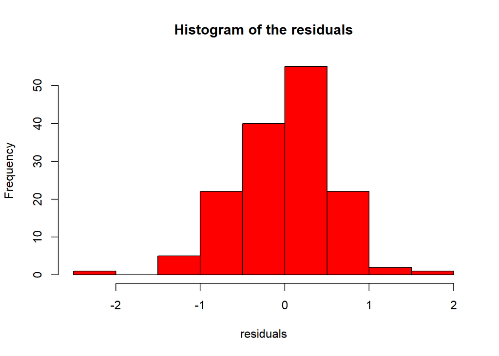

```r
my.anova.residuals<-residuals(anova.t4)
hist(my.anova.residuals,
     main = "Histogram of the residuals",
     col = "red",
     xlab = "residuals")
```

From the above we can see the residuals are not normally distributed since data points are negatively skewed. #Using QQ Plot

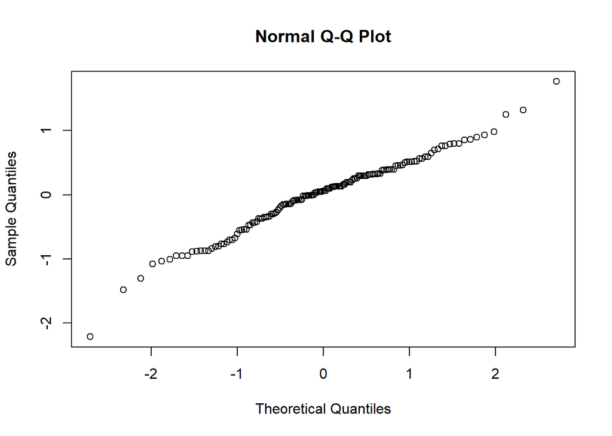

```r
qqnorm(my.anova.residuals)
```

#Task 5:Conducting Shapiro test and calculating effect size of the ANOVA test.

```r
shapiro.test(my.anova.residuals)
```

```
##
##  Shapiro-Wilk normality test
##
## data:  my.anova.residuals
## W = 0.97996, p-value = 0.02928
```

```r
library(car)
leveneTest(anova.t4)
```

```
## Levene's Test for Homogeneity of Variance (center = median)
##        Df F value Pr(>F)
## group   3  0.2859 0.8355
##       144
```

The test reveals a P-value>0.05 which indicates that there is no significant difference between the group variance.

Further I will perform regular factorial ANOVA since the normality assumption is violated.In this case I will apply Anova(),that is associated with te car package #Factorial ANOVA

```r
Anova(anova.t4,type=2)
```

```
## Anova Table (Type II tests)
##
## Response: mean_att_overall
##                   Sum Sq  Df F value    Pr(>F)
## animation          1.981   1  5.7448  0.017821 *
## tagline            7.004   1 20.3138 1.351e-05 ***
## animation:tagline  2.912   1  8.4452  0.004239 **
## Residuals         49.650 144
## ---
## Signif. codes:  0 '***' 0.001 '**' 0.01 '*' 0.05 '.' 0.1 ' ' 1
```

I also run a Kruskal-Wallis test on the main effect to see if there is still significant in a non-parametric test

```r
kruskal.test(formula=mean_att_overall~animation,data=statistics.data)
```

```
##
##  Kruskal-Wallis rank sum test
##
## data:  mean_att_overall by animation
## Kruskal-Wallis chi-squared = 5.8547, df = 1, p-value = 0.01554
```

```r
kruskal.test(formula=mean_att_overall~tagline,data = statistics.data)
```

```
##
##  Kruskal-Wallis rank sum test
##
## data:  mean_att_overall by tagline
## Kruskal-Wallis chi-squared = 17.677, df = 1, p-value = 2.617e-05
```

From the ANOVA output,we can see a significant effect for animation(F(1)=5.7,p<.05),a significant effect for tagline (F(1)=20.3,P<0.001),and a significant interaction effect (F(1)=8.4,P<.01).Also in Kruskal-Wallis test indicates significant effect for animation(Chi-squared(1)=5.9,p<.05) and for tagline(Chi-squared(1)=17.7,P<.001) Lastly,to calculate effect sizes,I used etaSquared() with a type II sum of squares

```r
etaSquared(anova.t4,type = 2)
```

```
##                       eta.sq eta.sq.part
## animation         0.03218073  0.03836371
## tagline           0.11379282  0.12362809
## animation:tagline 0.04730816  0.05539856
```

I also used Tukey’s HSD as a posthoc test

```r
TukeyHSD(anova.t4)
```

```
##   Tukey multiple comparisons of means
##     95% family-wise confidence level
##
## Fit: aov(formula = mean_att_overall ~ animation * tagline, data = statistics.data)
##
## $animation
##             diff        lwr       upr     p adj
## yes-no 0.2318029 0.04084028 0.4227656 0.0177057
##
## $tagline
##             diff      lwr       upr    p adj
## yes-no 0.4351241 0.244301 0.6259472 1.35e-05
##
## $`animation:tagline`
##                       diff        lwr       upr     p adj
## yes:no-no:no   -0.05303258 -0.4106085 0.3045433 0.9804523
## no:yes-no:no    0.16572200 -0.1821776 0.5136216 0.6036877
## yes:yes-no:no   0.67426901  0.3192877 1.0292503 0.0000128
## no:yes-yes:no   0.21875458 -0.1366166 0.5741257 0.3818582
## yes:yes-yes:no  0.72730159  0.3649948 1.0896084 0.0000037
## yes:yes-no:yes  0.50854701  0.1557867 0.8613073 0.0014591
```

#Task 7;Visualising the data by plotting the results and looking for an interaction effect

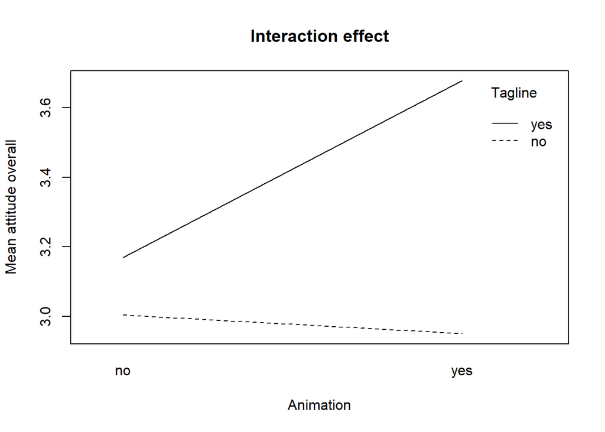

```r
interaction.plot(x.factor = statistics.data$animation,trace.factor = statistics.data$tagline,
                 response = statistics.data$mean_att_overall,
                 main="Interaction effect",
                 xlab = "Animation",
                 ylab = "Mean attitude overall",
                 trace.label = "Tagline")
```